# iAstrocytes Preprocessing QC statistics

### June 2025

```python
import os
NOVA_HOME = "/home/projects/hornsteinlab/Collaboration/NOVA_GAL/NOVA"
NOVA_DATA_HOME = '/home/projects/hornsteinlab/Collaboration/MOmaps'

LOGS_PATH = os.path.join(NOVA_DATA_HOME, "outputs/preprocessing/iAstrocytes/logs/")
PLOT_PATH = os.path.join(NOVA_DATA_HOME, "outputs/iAstrocytes/logs/")

root_directory_raw = '/home/projects/hornsteinlab/Collaboration/MOmaps/input/images/raw/John/iAstrocytes/ordered/'

os.chdir(NOVA_HOME)

import pandas as pd
import numpy as np
import contextlib
import io
from IPython.display import display, Javascript
import seaborn as sns
from tools.preprocessing_tools.qc_reports.qc_utils import log_files_qc, run_validate_folder_structure, display_diff, sample_and_calc_variance, \
                                                show_site_survival_dapi_brenner, show_site_survival_dapi_cellpose, \
                                                show_site_survival_dapi_tiling, show_site_survival_target_brenner, \
                                                calc_total_sums, plot_filtering_heatmap, show_total_sum_tables, \
                                                plot_cell_count, plot_catplot, plot_hm_combine_batches, plot_hm, \
                                                run_calc_hist_new, plot_marker_data, find_bad_wells,\
                                                show_site_survival_by_brenner_on_dapi_tiles, show_site_survival_target_brenner_tiles, \
                                                generate_configs_from_df

from tools.preprocessing_tools.qc_reports.qc_config import (
    iAstrocytes_markers as markers,
    iAstrocytes_cell_lines as cell_lines,
    iAstrocytes_cell_lines_to_cond as cell_lines_to_cond,
    iAstrocytes_cell_lines_for_disp as cell_lines_for_disp,
    iAstrocytes_reps as reps,
    iAstrocytes_line_colors as line_colors,
    iAstrocytes_lines_order as lines_order,
    iAstrocytes_custom_palette as custom_palette,
    iAstrocytes_expected_dapi_raw as expected_dapi_raw,
    iAstrocytes_panels as panels,
    iAstrocytes_marker_info as marker_info
)

from tools.show_images_utils import extract_image_metadata

%load_ext autoreload
%autoreload 2
```

```python
# choose batches
batches = ['batch1']
batches
```

```
['batch1']
```

```python
validate_antibody = False
```

```python
df = log_files_qc(LOGS_PATH, batches, only_wt_cond = False)
```

```
reading logs of batch1

Total of 1 files were read.
Before dup handeling  (1652, 22)
After duplication removal #1: (1652, 23)
After duplication removal #2: (1652, 23)
```

```python
df['filename'] = df['filename'].str.split('-').str[0]
df['site_num'] = df['site_num'].str.split('-').str[0]
```

```python
df_dapi = df[df.marker=='DAPI']
df_target = df[df.marker!='DAPI']
```

## Actual Files Validation

### Raw Files Validation

1. How many site **tiff** files do we have in each folder?
2. Are all existing files valid? (tif, at least 2049kB, not corrupetd)

```python
df_metadata = extract_image_metadata(root_directory_raw, FILE_EXTENSION = '.tiff', KEY_BATCH = 'batch')
```

```python
df_metadata['CellLine'].value_counts()
```

```
CellLine
WT    864
C9    864
Name: count, dtype: int64
```

```python
# generate_configs_from_df(df_metadata, prefix="iAstrocytes")
```

Expected -

ARL13B - 18 (1 panel)

PML - 36 (2 panels)

TDP-43 - 18 (1 panel)

Vimentin - 72 (4 panels)

WDR49 - 54 (3 panels)

DAPI - 72 (4 panels)

```
batch1
Folder structure is valid.
No bad files are found.
Total Sites:  1728
```

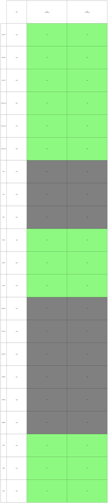

```python
batches_raw = [batch.replace("_16bit_no_downsample","") for batch in batches]
raws = run_validate_folder_structure(root_directory_raw, False, panels, markers.copy(), PLOT_PATH, marker_info,
                                    cell_lines_to_cond, reps, cell_lines_for_disp, expected_dapi_raw,
                                     batches=batches_raw, fig_width=8,fig_height = 40,
                                    expected_count=18, validate_antibody = validate_antibody)
```

### Processed Files Validation

1. How many site **npy** files do we have in each folder? -> How many sites survived the pre-processing?
2. Are all existing files valid? (at least 100kB, npy not corrupted)

```
batch1
Folder structure is valid.
No bad files are found.
Total Sites:  1650
```

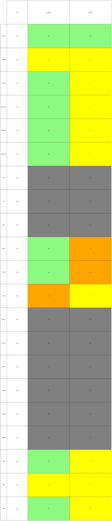

```python
root_directory_proc = os.path.join(NOVA_DATA_HOME, 'input', 'images', 'processed', 'iAstrocytes')
procs = run_validate_folder_structure(root_directory_proc, True, panels, markers, PLOT_PATH, marker_info,
                                    cell_lines_to_cond, reps, cell_lines_for_disp, expected_dapi_raw,
                                     batches=batches, fig_width=8,fig_height = 40,
                                    expected_count=18, validate_antibody = validate_antibody)
```

### Difference between Raw and Processed

```
batch1
```

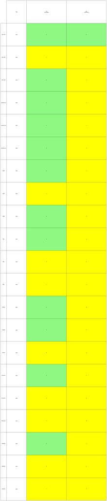

```python
display_diff(batches, raws, procs, PLOT_PATH, fig_width=8, fig_height = 40)
```

### Variance in each batch (of processed files)

```python
for batch in batches:
    with contextlib.redirect_stdout(io.StringIO()):
        var = sample_and_calc_variance(root_directory_proc, batch,
                                       sample_size_per_markers=200, cond_count=1, rep_count=len(reps),
                                       num_markers=len(markers))
    print(f'{batch} var: ',var)
```

```
batch1 var:  0.028558825575337322
```

## Preprocessing Filtering qc

By order of filtering

### 1. % site survival after Brenner on DAPI channel

Percentage out of the total sites

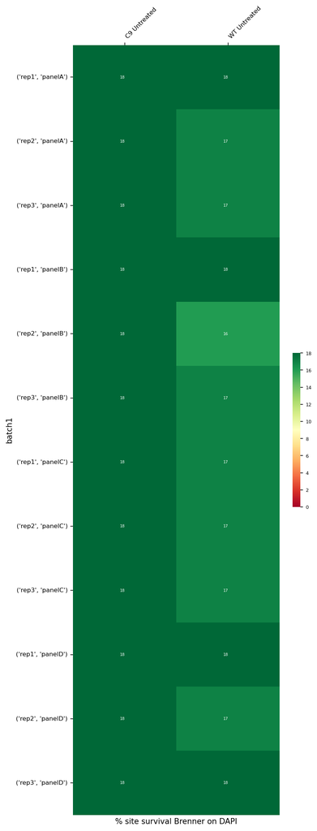

```python
dapi_filter_by_brenner = show_site_survival_dapi_brenner(df_dapi,batches, line_colors, panels,
                                                        figsize=(6,18), reps=reps, vmax=18) ## 72/n_panels
```

### 2. % Site survival after Cellpose

Percentage out of the sites that passed the previous filter. In parenthesis are absolute values.

**A site will be filtered out if Cellpose found 0 cells in it.**

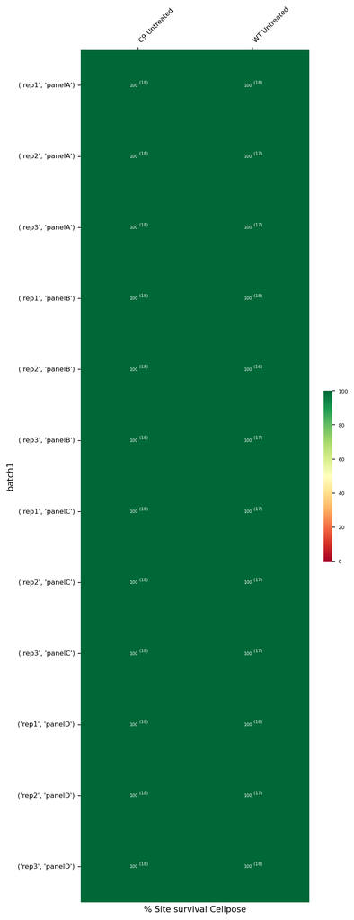

```python
dapi_filter_by_cellpose = show_site_survival_dapi_cellpose(df_dapi, batches, dapi_filter_by_brenner,
                                                           line_colors, panels, figsize=(6,18), reps=reps)
```

### 3. % Site survival by tiling

Percentage out of the sites that passed the previous filter. In parenthesis are absolute values.

**A site will be filtered out if after tiling, no tile is containing at least 85% of a cell that Cellpose detected.**

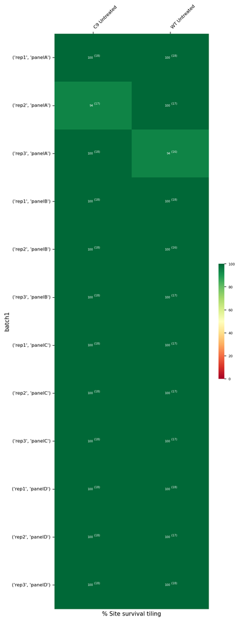

```python
dapi_filter_by_tiling=show_site_survival_dapi_tiling(df_dapi, batches, dapi_filter_by_cellpose,
                                                     line_colors, panels, figsize=(6,18), reps=reps)
```

### 4. % Site survival after Brenner on target channel

Percentage out of the sites that passed the previous filter. In parenthesis are absolute values (if different than the percentages).

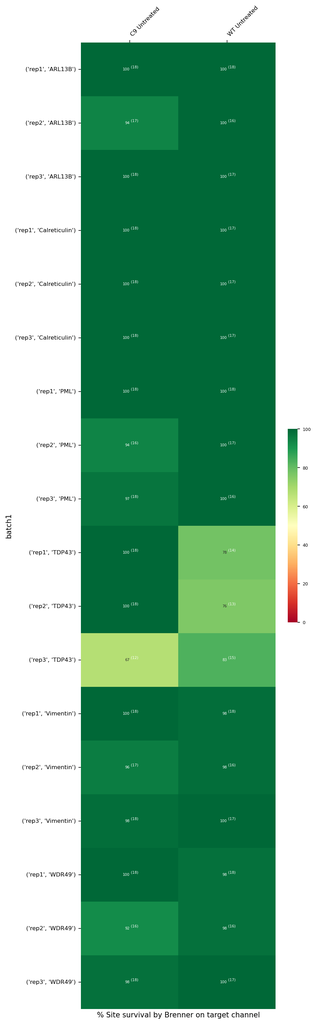

```python
show_site_survival_target_brenner(df_dapi, df_target, dapi_filter_by_tiling,
                                 figsize=(6,24), markers=markers)
```

Find potential non valid wells (high Brenner scores)

```python
dfb = pd.read_csv("/home/projects/hornsteinlab/Collaboration/MOmaps/outputs/preprocessing/iAstrocytes/brenner/raw_metrics110625.csv")
# Extract the panel (e.g., "panelD") from the Path column
dfb['Panel'] = dfb['Path'].str.extract(r'/panel([A-Z])/', expand=True)
find_bad_wells(dfb, threshold=10000, percentage_filter=60)
```

|  | CellLine | Rep | Marker | Count_bad | Count_total | Percentage | Combination | Panel | Condition | Batch |
| --- | --- | --- | --- | --- | --- | --- | --- | --- | --- | --- |
| 0 | C9 | rep2 | Calreticulin | 11 | 18 | 61.111111 | ['CellLine', 'Rep', 'Marker'] | NaN | NaN | NaN |
| 1 | WT | rep3 | ARL13B | 12 | 18 | 66.666667 | ['CellLine', 'Rep', 'Marker'] | NaN | NaN | NaN |

Checked - those wells are valid (contain a lot of signal)

## Statistics About the Processed Files

```python
names = ['Total number of tiles', 'Total number of whole cells']
stats = ['n_valid_tiles','site_whole_cells_counts_sum','site_cell_count','site_cell_count_sum']
total_sum = calc_total_sums(df_target, df_dapi, stats, markers)
```

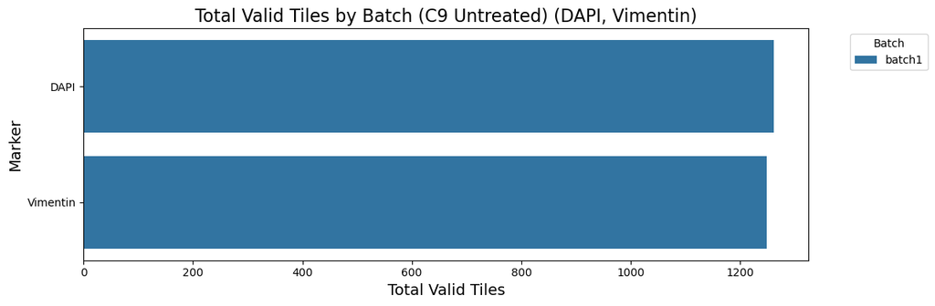

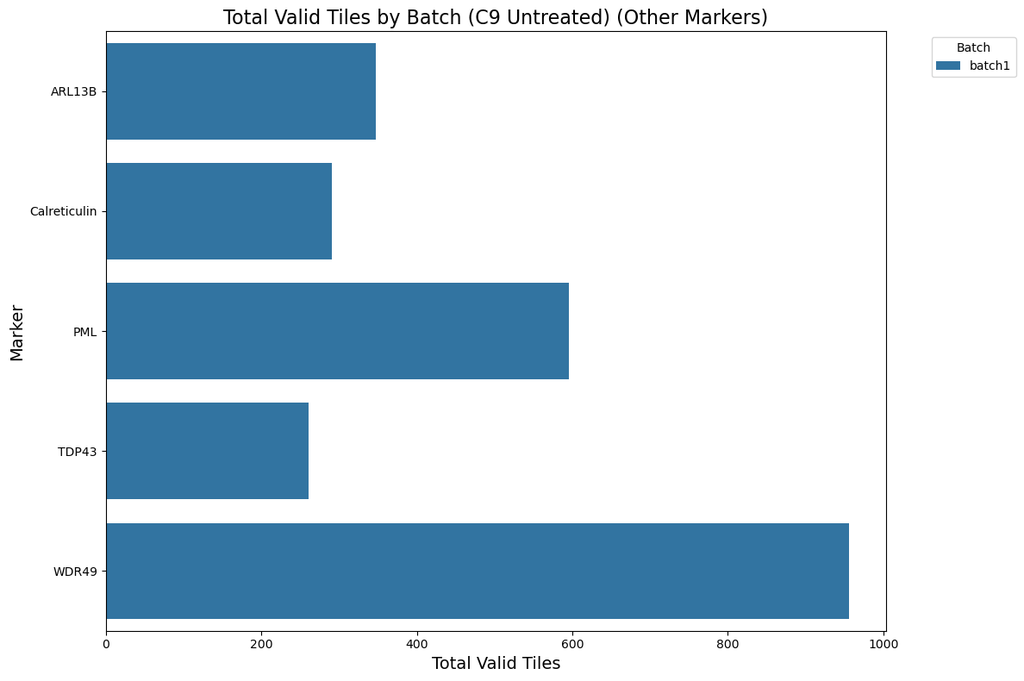

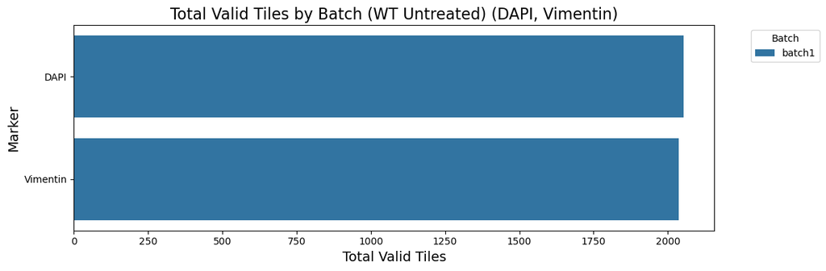

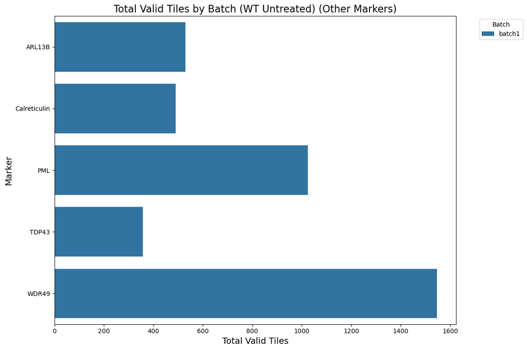

```python
plot_marker_data(total_sum, split_by_cell_line=True, separate_markers = ['DAPI', 'Vimentin'])
```

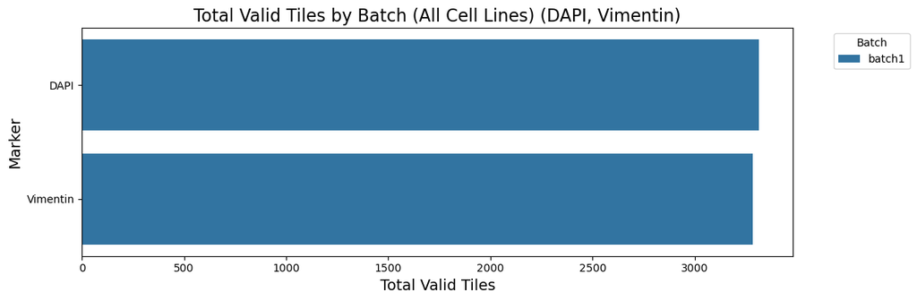

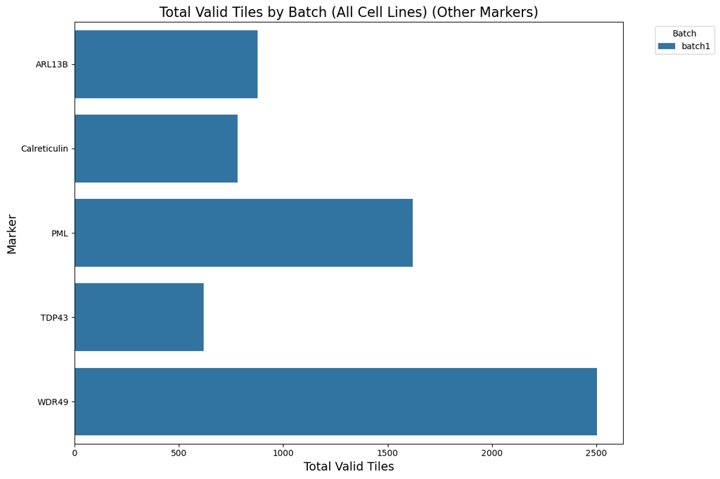

```python
plot_marker_data(total_sum, split_by_cell_line=False, separate_markers = ['DAPI', 'Vimentin'])
```

### Total tiles

```python
total_sum.n_valid_tiles.sum()
```

```
13001
```

### Total whole nuclei in tiles

```python
total_sum[total_sum.marker =='DAPI'].site_whole_cells_counts_sum.sum()
```

```
645.0
```

### Total nuclei in sites

```python
total_sum[total_sum.marker =='DAPI'].site_cell_count.sum()
```

```
9340.0
```

```python
show_total_sum_tables(total_sum)
```

| batch1 | n_valid_tiles | % valid tiles | site_whole_cells_counts_sum | site_cell_count |
| --- | --- | --- | --- | --- |
| count | 96.000000 | 96.000000 | 96.000000 | 96.000000 |
| mean | 135.427083 | 1.354271 | 26.427083 | 381.322917 |
| std | 37.974713 | 0.379747 | 11.625512 | 103.213677 |
| min | 67.000000 | 0.670000 | 8.000000 | 171.000000 |
| 25% | 102.000000 | 1.020000 | 16.000000 | 300.000000 |
| 50% | 135.500000 | 1.355000 | 25.000000 | 341.000000 |
| 75% | 162.500000 | 1.625000 | 35.000000 | 459.000000 |
| max | 205.000000 | 2.050000 | 48.000000 | 612.000000 |
| sum | 13001.000000 | NaN | 2537.000000 | 36607.000000 |
| expected_count | 450.000000 | 450.000000 | 450.000000 | 450.000000 |

| All batches | n valid tiles | % valid tiles | site_whole_cells_counts_sum | site_cell_count |
| --- | --- | --- | --- | --- |
| count | 96.000000 | 96.000000 | 96.000000 | 96.000000 |
| mean | 135.427083 | 1.354271 | 26.427083 | 381.322917 |
| std | 37.974713 | 0.379747 | 11.625512 | 103.213677 |
| min | 67.000000 | 0.670000 | 8.000000 | 171.000000 |
| 25% | 102.000000 | 1.020000 | 16.000000 | 300.000000 |
| 50% | 135.500000 | 1.355000 | 25.000000 | 341.000000 |
| 75% | 162.500000 | 1.625000 | 35.000000 | 459.000000 |
| max | 205.000000 | 2.050000 | 48.000000 | 612.000000 |
| sum | 13001.000000 | NaN | 2537.000000 | 36607.000000 |
| expected_count | 450.000000 | 450.000000 | 450.000000 | 450.000000 |

### Show Total Tile Counts

For each batch, cell line, replicate and markerTotal number of tiles

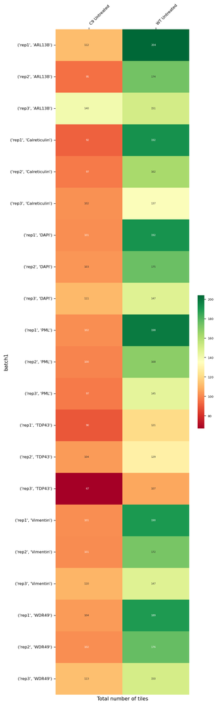

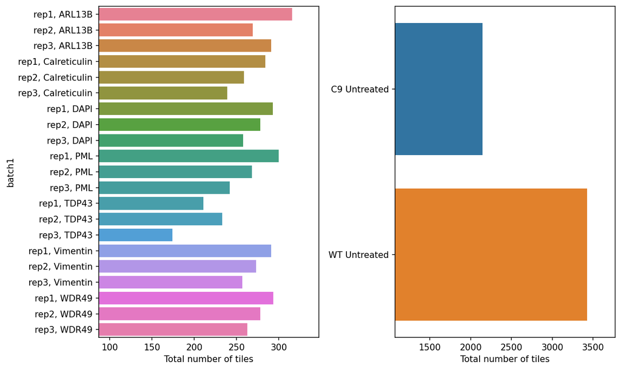

```python
to_heatmap = total_sum.rename(columns={'n_valid_tiles':'index'})
plot_filtering_heatmap(to_heatmap, extra_index='marker', vmin=None, vmax=None,
                      xlabel = 'Total number of tiles', show_sum=True, figsize=(6,24))
```

### Show Total Whole Cell Counts

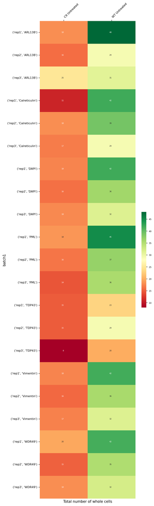

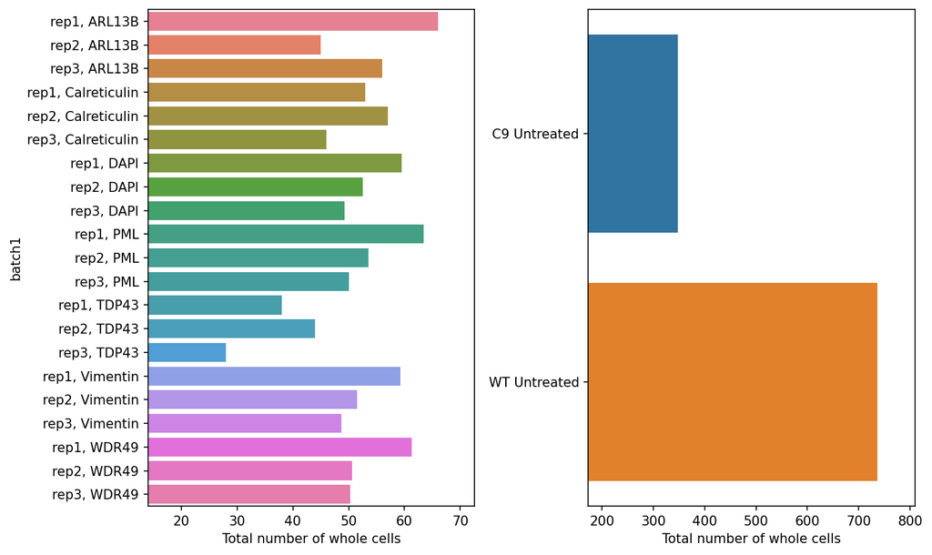

```python
to_heatmap = total_sum.rename(columns={'site_whole_cells_counts_sum':'index'})
plot_filtering_heatmap(to_heatmap, extra_index='marker', vmin=None, vmax=None,
                      xlabel = 'Total number of whole cells', show_sum=True, figsize=(6,24))
```

### Show **Cell Count** Statistics per Batch

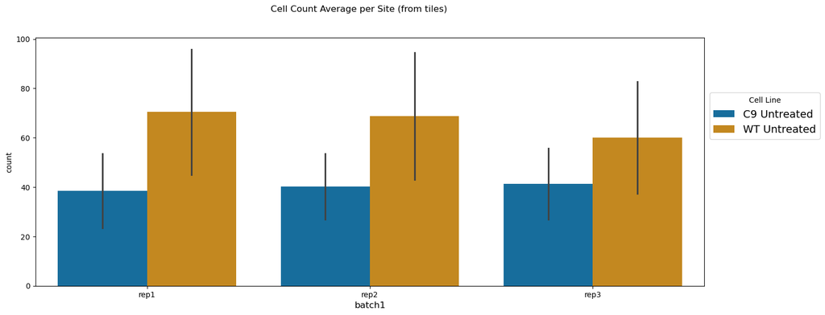

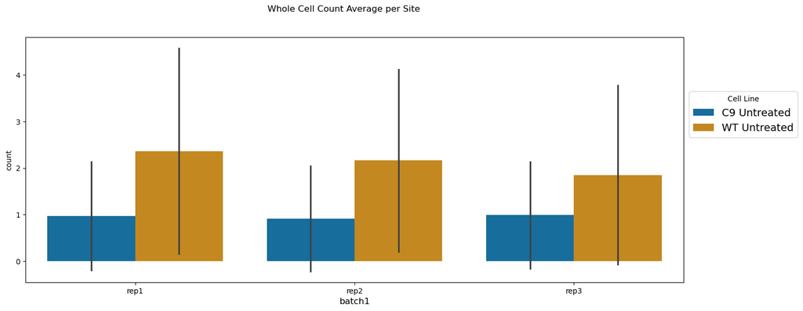

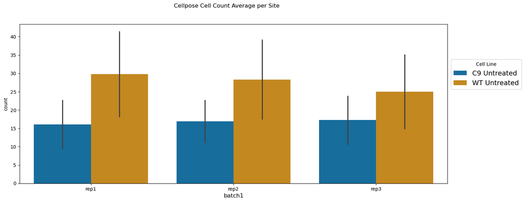

```python
df_no_empty_sites = df_dapi[df_dapi.n_valid_tiles_after_tiles_brenner !=0]
plot_cell_count(df_no_empty_sites, lines_order, custom_palette, y='site_cell_count_sum',
                title='Cell Count Average per Site (from tiles)', figsize=(16,6))

plot_cell_count(df_no_empty_sites, lines_order, custom_palette, y='site_whole_cells_counts_sum',
                title='Whole Cell Count Average per Site',figsize=(16,6))

plot_cell_count(df_no_empty_sites, lines_order, custom_palette, y='site_cell_count',
               title='Cellpose Cell Count Average per Site',figsize=(16,6))
```

### Show **Tiles** per Site Statistics

```python
df_dapi.groupby(['cell_line_cond']).n_valid_tiles_after_tiles_brenner.mean()
```

```
cell_line_cond
C9 Untreated    5.842593
WT Untreated    9.922705
Name: n_valid_tiles_after_tiles_brenner, dtype: float64
```

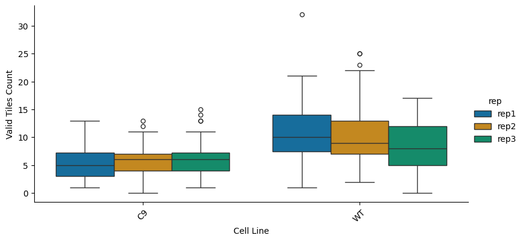

```python
plot_catplot(df_dapi, sns.color_palette('colorblind'), reps=reps,x='cell_line', y_title='Valid Tiles Count', x_title='Cell Line', y='n_valid_tiles_after_tiles_brenner', hue='rep',
             height=4, aspect=2)
```

```python
# save notebook as HTML ( the HTML will be saved in the same folder the original script is)
display(Javascript('IPython.notebook.save_checkpoint();'))
os.system(f'jupyter nbconvert --to html tools/preprocessing_tools/qc_reports/qc_report_iAstrocytes.ipynb --output {NOVA_HOME}/manuscript/preprocessing_qc_reports/qc_report_iAstrocytes.html')
```